This protocol contains all elements from the [STROBE](http://www.strobe-statement.org/) statement and was generated using [spiritR](http://www.github.com/awconway/spiritR/)

# Research Protocol

Predicting apnea during procedural sedation

Version 1

02 May, 2019

| Study Principal Investigator: | **Aaron Conway, RN, PhD** RBC Chair in Cardiovascular Nursing Research Peter Munk Cardiac Centre, Toronto General Hospital, University Health Network Assistant Professor Lawrence S. Bloomberg Faculty … |
| --- | --- |
| Sponsors: | Investigator-sponsored trial |
| Protocol contributors: | **Peter Collins, MA** Research Associate Peter Munk Cardiac Centre, Toronto General Hospital, University Health Network **Matteo Parotto, MD, PhD** Assistant Professor, Department of Anesthesia and In… |
| Trial identifiers: | CAPCR |

**ABBREVIATIONS**

| Abbreviation | Explanation |
| --- | --- |
| PHI | Personal Health Information |
| PI | Principal Investigator |
| RA | Research Assistant |
| REB | Research Ethics Board |
| ETCO<sub>2</sub> | End-tidal carbon dioxide |
| SpO<sub>2</sub> | Percentage of hemoglobin saturated with oxygen |

**REVISION HISTORY**

| Version | Date | Amendment Text | Description |
| --- | --- | --- | --- |

# 1 TRIAL SUMMARY

[output not shown]

# 2 INTRODUCTION

## 2.1 Background and rationale

> A capnography waveform displays the level of expired carbon dioxide (CO<sub>2</sub>) over time to show changes in concentrations throughout the respiratory cycle. Capnography waveform abnormalities assist in the detection and diagnosis of specific conditions, such as partial airway obstruction and apnea. For this reason, implementing capnography into practice for respiratory monitoring during sedation is considered a high priority to improve patient safety by leading authorities including peak professional organisations for anaesthesia in Canada, the United States and Europe.<sup>1–3</sup>

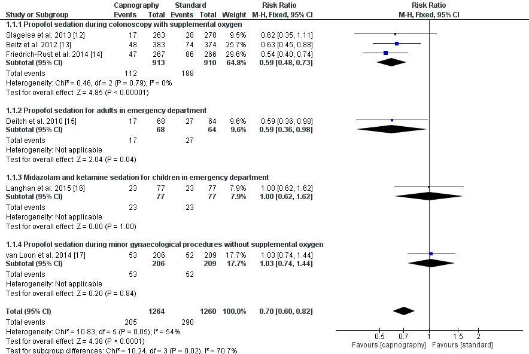

A more recent randomized controlled trial conduced in the context of moderate sedation (otherwise known as ‘conscious’ sedation) found that capnography did not reduce the rate of hypoxemia.<sup>5</sup> Likewise, a large randomised controlled trial that supplied higher flows of oxygen during deep sedation performed with propofol in the Emergency Department also found that the rates of hypoxemia were not significantly different between groups randomized to monitoring with or without capnography.<sup>6</sup> Moreover, a potential unintended consequence of implementing capnography for procedural sedation is a decrease in sedation efficacy due to increased procedural interruptions prompted in response to alarms. A recent evaluation of the implementation of capnography using a threshold-based alarm (triggered at 15 seconds of apnoea) during endoscopy with nurse-administered sedation indicated that introduction of capnography monitoring was associated with increased ratings of procedural discomfort by patients and clinicians.<sup>7</sup> Another potential consequence to consider is alarm fatigue. Alarm fatigue has been linked to patient deaths resulting from clinicians becoming desensitised to alarms leading to delayed responses to clinical deterioration.<sup>8</sup>

Deciphering which capnography waveform abnormalities deserve intervention (and therefore alarms to signal the event to clinicians) from those that do not is an essential step towards successful implementation of this technology into practice. For example, triggering alarms after short periods of apnea leads to frequent procedural interruptions and decreases sedation efficacy.<sup>7</sup> Conversely, only intervening once an apneic period reaches a longer threshold negates the potential benefits of capnography on sedation safety by improving ventilation.

> It would be ideal for clinicians to receive capnography monitor alarms as *early as possible* in the course of an apneic event; *but only* if the event will be prolonged for enough time for a clinical intervention to be implemented and exert its intended effect.

To expand, triggering an alarm after 30 seconds of apnea that would have self-resolved without clinical intervention only 5 seconds later is just as clinically inconsequential as triggering an alert after 5 seconds of apnea that would similarly have resolved after a short period of time. In both of these circumstances there would not have been enough time for the clinician’s intervention to take effect. Yet, presumably in an attempt to reduce alarm burden, capnography monitor alarms now mostly default to triggering after apnea has been observed for 30 seconds. Many apneic periods in patients who receive conscious sedation will self-resolve shortly after this 30-second alarm.

> We propose that the current approach to capnography monitor alarm management may be improved upon by using machine learning to create a ‘smart alarm’ that can alert clinicians *only* if an apneic event is predicted to be prolonged.

This approach responds to a call from The Society for Critical Care Medicine Alarm and Alert Fatigue Task Force, that machine learning techniques should be used to advance the quality of alerts that clinicians receive and to individualise alert delivery based on clinician response characteristics, such as alert frequency and severity.

Based on results from our preliminary work, it seems that using information about the history of previous respiratory states may be a promising solution in regards to predicting durations of apneic periods. In this work we examined capnography waveform abnormalitites that occured during procedural sedation with bolus doses of midazolam and fentanyl using a statistical approach known as State Sequence Analysis. Respiratory state sequences for 102 patients who had a procedure in a cardiac catheterisation laboratory with procedural sedation and analgesia were developed by classifying each second of procedures into a state of normal breathing or other capnography waveform abnormalities based on pre-specified cut-offs for respiratory rate and end-tidal CO2 concentration. Analysis of the respiratory state sequences clearly demonstrated that capnography waveform abnormalities are frequent and prolonged in this population. Applying a clustering algorithm to group similar respiratory state sequences revealed insights into common patterns of ventilatory responses to the medication used for procedural sedation.

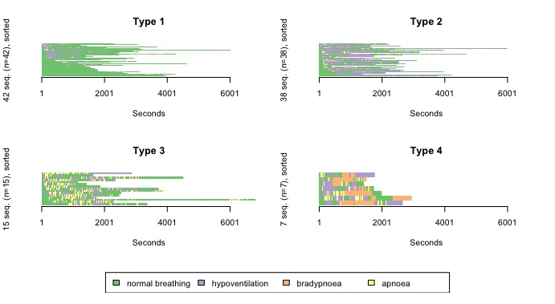

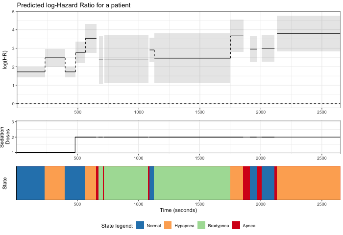

Results from prior research in a different population also supports our observations that the onset of apneic periods during sedation are associated with the history of previous respiratory states. Krauss and colleages<sup>9</sup> used survival analysis to model the time to first apneic events in a sample of 312 patients undergoing procedural sedation with propofol or ketamine in the emergency department. It was identified that having an abnormal ETCO<sub>2</sub> measurement 30, 60 and 90 seconds prior to an apneic event increased risk for apnea (hazard ratios with 95% CI for the different lag durations of 2.45 (1.63 - 3.69), 1.88 (1.21 - 2.92) and 2.06 (1.36 - 3.11), respectively).

> We now plan to build on these preliminary findings about the associations between apneic events and the history of previous respiratory states by building a predictive model from a large sample of capnography waveforms.

Capnography waveforms collected through the Drug Reconciliation and Electronic Anesthesia Monitoring system during cardiac implantable electronic device procedures performed with conscious sedation administered by Anesthesia Assistants at the Peter Munk Cardiac Centre over the past five years (approximately 2000 patients) will be analysed. Long short-term memory recurrent neural networks (LSTM) will be used to train a model to predict the remaining duration of an ongoing apneic episode. An LSTM model is particularly suited to this prediction problem because it can naturally model time series data exhibiting non-linear and long-term dependencies on a set of time-varying predictors. Once the model is learned, it can produce predictions at any specified set of time horizons. This feature will be utilised to develop the smart alarm by making predictions based on previous states in unobserved data that an apneic period will be prolonged. The final model will be chosen with respect to the optimal balance between accurately predicting ETCO<sub>2</sub>, and thus prolonged apneic periods, and the alarm frequency reduction rate (AFRR). The AFRR metric is the ratio of correct predictions of short apneic periods to the total number of apneic periods.

> Longer term plans for this program of research are to prospectively evaluate the accuracy of the model developed in the current study, develop a Graphical User Interface that is best suited to operationalise the predictive model as a ‘smart alarm’ in the clinical setting and, ultimately, conduct a randomized controlled trial to test the clinical safety and utility of the ‘smart alarm’.

## 2.2 Objectives

This study aims to develop and validate a machine-learning predictive model for apnea in patients undergoing a cardiac implantable electronic device procedure with conscious sedation administered by an Anesthesia Assistant.

# 3 METHODS

## 3.1 Study Design

This study will use a Retrospective, Cohort design.

## 3.2 Study setting

Peter Munk Cardiac Centre Cardiac Cath Labs at Toronto General Hospital, University Health Network.

## 3.3 Participants

Patients receiving procedural sedation in a cardiac catheterisation laboratory

### 3.3.1 Inclusion criteria

Received sedation

### 3.3.2 Exclusion criteria

None

## 3.4 Definition of Key Variables

> Primary outcome: Apnea

*Timeframe*: From the time between first sedative medication administration to the end of the procedure. Estimated duration of procedures is 30 minutes to 120 minutes.

*Description*: Defined as a ETCO<sub>2</sub> measurement of less than 10 mmHg

> Predictor variables

As the ultimate aim of this program of research is to imporve capnography monitor alarm parameters, the predictor variables are limited to either only those available within the monitoring system or those that can easily be entered into it. Although it is not currently common practice for users of stand-alone capnography monitors to input sedation doses as the medication is administered, this functionality is routinely used for anesthetic monitoring systems (i.e. DREAM). As such, we will include dosages of medications as variables in the predictive modelling.

1. End-tidal carbon dioxide concentration
2. Respiratory rate - derived from capnography waveform
3. Dosage of midazolam
4. Dosage of fentanyl (or other opioid used)
5. Dosage of propofol

### 3.4.1 Prediction Goal

The prediction goal is the duration of apneic events. These predictions will be ‘operationalised’ as a ‘smart-alarm’ by triggering an alert if an apneic event is predicted to last for more than 20 seconds. The ‘prediction algorithm’ will be compared against a ‘default’ alarm setting for capnography monitors, which triggers an alarm at 30 seconds of apnea. A ‘correct’ prediction for both settings will be when apnea continues for a further 20 seconds or more after the alert is triggered.

## 3.5 Sample size

The sample size for this study will be drawn from the number of procedures performed with conscious sedation by Anesthesia Assistants in the cath lab over a five year period. It is expected that this will be approximately 2000 patients.

## 3.6 Data collection

### 3.6.1 Procedures and evaluations

## 3.7 Data management

**Data Forms and Data Entry**

A case report form developed in REDCap to extract information about the demographic characteristics of the sample. All personal information such as the patient's name, date of birth, health information, and UHN MRN will be removed from the data and will be replaced with a participant ID number.

**Data Transmission and Editing**

Using REDCap<sup>TM</sup>, range checks will be applied to minimize errors in data entry.

**Security and Back-Up of Data**

All forms related to study data will be kept in locked cabinets. Access to the study data will be restricted. A password system will be utilized to control access to electronic files related to the study on a secure UHN Network in compliance with UHN's policy and procedural manual on storage, transport and destruction of confidential information. These passwords will be changed on a regular basis. In compliance with UHN's policy & procedure manual on “Research: Data Ownership, Stewardship & Security of Health Information”, the institution will be responsible for providing hard data backs ups of all UHN Information and Technology (IT) systems for disaster recovery purposes.

## 3.8 Statistical methods

We will develop an LSTM model to predict the remaining duration of an ongoing apenic episode. Inputs of the model will be a multivariate time-series consisting of the current values of EtCO<sub>2</sub>, respiratory rate, the capnography waveform, and the cumulative doses of Midazolam, fentanyl, and propofol. Since we are interested in predicting the length of an ongoing apneic episode, we will consider only data where the most recent ETCO<sub>2</sub> measurement is under 10mmHg.

The sample data will be partitioned into a training and test set following an 80/20 split across patients. A subset of data within the training set will be set aside for model validation purposes. To ensure that these partitions are representative of the sample, the sample will be stratified among clusters of patients exhibiting similar procedure durations and number of apneic episodes.

Hyperparameters of the model will be chosen by evaluating the performance of the model on the validation data. The performance of each model will be evaluated using the mean square error loss.

### 3.8.1 Additional analyses

No additional analyses will be performed.

### 3.8.2 Analysis population and missing data

## 3.9 Data monitoring

### 3.9.1 Formal committee

# 4 ETHICS AND DISSEMINATION

## 4.1 Research ethics approval

This protocol will be reviewed and approved by the sponsor and entered into the Coordinated Approval Process for Clinical Research (CAPCR) to receive approval from UHN's Research Ethics Board (REB) and Institutional Authorization with respect to scientific content and compliance with applicable research and human subjects regulations.

The protocol and other requested documents — and any subsequent modifications — will also be submitted through CAPCR to be reviewed by UHN's REB for ethics approval, and the Executive Vice President of Science and Research or designate for institutional authorization.

Subsequent to initial review and approval, an annual study renewal will be submitted to CAPCR for the UHN's REB to review at least 14-30 days before the study's REB expiry date. The Investigator will make safety and progress reports to the REB at least annually and within three months of study termination or completion at the study site.

## 4.3 Informed consent process

Informed consent will not be sought for this study, as it will only involve analysis of data already collected as part of routine practice. It would also not be feasible to contact patients for their consent to participate due to the large number of patients’ medical records to be reviewed.

### 4.3.1 Ancillary studies

No biological specimens will be collected in this trial. Data collected in this trial will not be used in ancillary studies.

## 4.4 Confidentiality

All study-related information will be stored securely in compliance with UHN's “Storage, Transport & Destruction of Confidential Information” policy. All participant information will be stored in locked file cabinets in areas with limited access. The types of Participant Health Information (PHI) that will be collected for this study have been limited to that which is necessary for the purposes of the research study, and will be de-identified. PHI will not be used or disclosed for purposes other than those which it was collected, except with the express consent of the individual or as required by law. All personal information such as the patient's name, date of birth, health information, and UHN MRN will be removed from the data and will be replaced with a participant ID number. A list linking the participant ID number with patient names will be stored in an electronic file by the study team on a secure UHN Network. Thus, all reports, data collection, process, and administrative forms will be de-identified.

All information collected during this study, including PHI, will be kept confidential and will not be shared with anyone outside the study unless required by law. Participants will not be named in any reports, publications, or presentations that may come from this study. Participant de-identified data from this study may be used for other research purposes. If the study data is shared with other researchers, information that links study data directly to the participant will not be shared.

## 4.5 Declaration of interests

There are no conflict of interests to declare.

## 4.6 Access to data

All members of the study team will be given access to the cleaned data sets. The study data sets will be housed on the UHN computer system, and all data sets will be password protected. To ensure confidentiality, data dispersed to the study team members will not contain any identifying participant information.

## 4.7 Dissemination policy

### 4.7.1 Study results

The study results will be reported in publications and presentations.

### 4.7.2 Authorship

The study's investigators will be authors on the reporting and presentation of the trial's results. Topics suggested for presentation or publication will be circulated among the study team.

### 4.7.3 Reproducible research

*Inidividual participant data sharing statement*

Study data, participant-level data sets (without identifying information) and code for statistical analyses will be shared in a publicly accessible repository at the time of publication.

*Individual participant data sharing time-frame statement*

Participant-level data sets (without identifying information) will be made available at the time of publication of results.

# 5 STUDY ADMINISTRATION

## 5.1 Key contacts

**Study Principal Investigator**

Aaron Conway, RN, PhD

RBC Chair in Cardiovascular Nursing Research Peter Munk Cardiac Centre Toronto General Hospital University Health Network Assistant Professor Lawrence S. Bloomberg Faculty of Nursing University of Toronto

Toronto General Hospital Heart & Circulation Admin 4NU - 476 585 University Ave Toronto, ON M5G 2N2

416. 340-4654

aaron.conway@uhn.ca

**Central contact**

Aaron Conway

Phone: (416) 340-4654

Email:aaron.conway@uhn.ca

**Sponsor**

University Health Network, Toronto

## 5.2 Funders

PI Conway has received the Lawrence S. Bloomberg 2019 Bertha Rosenstadt Faculty Small Research Grant to conduct this study

## 5.3 Roles and responsibilities

### 5.3.1 Protocol contributors

AC conceived of the study. AC, MP, PL, ALF, PC contributed to the study design. All authors contributed to refinement of the study protocol and will approve the final manuscripts of results. PC will conduct the analyses.

### 5.3.2 Sponsor and funder

The funding source will not have any role during its execution, analyses, interpretation of the data, or decision to submit results.

### 5.3.3 Trial committees

N/A

# 6 REFERENCES

# Appendix

1. Apfelbaum, J. *et al.* Practice guidelines for moderate procedural sedation and analgesia 2018: A report by the American Society of Anesthesiologists Task Force on Moderate Procedural Sedation and Analgesia, the American Association of Oral and Maxillofacial Surgeons, American College of Radiology, American Dental Association, American Society of Dentist Anesthesiologists, and Society of Interventional Radiology. *Anesthesiology* **128**, 437–79 (2018).

2. Hinkelbein, J. *et al.* European Society of Anaesthesiology and European Board of Anaesthesiology guidelines for procedural sedation and analgesia in adults. *European Journal of Anaesthesiology (EJA)* **35**, 6–24 (2018).

3. Dobson, G. *et al.* Procedural sedation: A position paper of the Canadian Anesthesiologists’ Society. *Canadian Journal of Anesthesia/Journal canadien d’anesthésie* **65**, 1372–1384 (2018).

4. Conway, A., Douglas, C. & Sutherland, J. R. A systematic review of capnography for sedation. *Anaesthesia* **71**, 450–454 (2016).

5. Mehta, P. P. *et al.* Capnographic monitoring in routine EGD and colonoscopy with moderate sedation: A prospective, randomized, controlled trial. *The American journal of gastroenterology* **111**, 395–395 (2016).

6. Campbell, S. G. *et al.* End-tidal capnometry during emergency department procedural sedation and analgesia: A randomized, controlled study. *World journal of emergency medicine* **7**, 13 (2016).

7. Barnett, S. *et al.* Capnographic monitoring of moderate sedation during low-risk screening colonoscopy does not improve safety or patient satisfaction: A prospective cohort study. *The American journal of gastroenterology* **111**, 388 (2016).

8. Chopra, V. & McMahon, L. F. Redesigning hospital alarms for patient safety: Alarmed and potentially dangerous. *JAMA* **311**, 1199–1200 (2014).

9. Krauss, B. S., Andolfatto, G., Krauss, B. A., Mieloszyk, R. J. & Monuteaux, M. C. Characteristics of and predictors for apnea and clinical interventions during procedural sedation. *Annals of emergency medicine* **68**, 564–573 (2016).